# Risk Factor Analysis

## Outcome Variable

**Outcome Variable:** pers_wasted624

## Predictor Variables

**Intervention Variable:** ever_underweight06

**Adjustment Set:**

unadjusted

## Stratifying Variables

The analysis was stratified on these variable(s):

- studyid
- country

## Data Summary

| studyid | country | ever_underweight06 | pers_wasted624 | n_cell | n |
| --- | --- | --- | --- | --- | --- |
| ki0047075b-MAL-ED | BANGLADESH | 0 | 0 | 163 | 240 |
| ki0047075b-MAL-ED | BANGLADESH | 0 | 1 | 5 | 240 |
| ki0047075b-MAL-ED | BANGLADESH | 1 | 0 | 59 | 240 |
| ki0047075b-MAL-ED | BANGLADESH | 1 | 1 | 13 | 240 |
| ki0047075b-MAL-ED | BRAZIL | 0 | 0 | 190 | 202 |
| ki0047075b-MAL-ED | BRAZIL | 0 | 1 | 2 | 202 |
| ki0047075b-MAL-ED | BRAZIL | 1 | 0 | 10 | 202 |
| ki0047075b-MAL-ED | BRAZIL | 1 | 1 | 0 | 202 |
| ki0047075b-MAL-ED | INDIA | 0 | 0 | 142 | 234 |
| ki0047075b-MAL-ED | INDIA | 0 | 1 | 1 | 234 |
| ki0047075b-MAL-ED | INDIA | 1 | 0 | 64 | 234 |
| ki0047075b-MAL-ED | INDIA | 1 | 1 | 27 | 234 |
| ki0047075b-MAL-ED | NEPAL | 0 | 0 | 198 | 234 |
| ki0047075b-MAL-ED | NEPAL | 0 | 1 | 0 | 234 |
| ki0047075b-MAL-ED | NEPAL | 1 | 0 | 34 | 234 |
| ki0047075b-MAL-ED | NEPAL | 1 | 1 | 2 | 234 |
| ki0047075b-MAL-ED | PERU | 0 | 0 | 223 | 264 |
| ki0047075b-MAL-ED | PERU | 0 | 1 | 1 | 264 |
| ki0047075b-MAL-ED | PERU | 1 | 0 | 39 | 264 |
| ki0047075b-MAL-ED | PERU | 1 | 1 | 1 | 264 |
| ki0047075b-MAL-ED | SOUTH AFRICA | 0 | 0 | 221 | 258 |
| ki0047075b-MAL-ED | SOUTH AFRICA | 0 | 1 | 0 | 258 |
| ki0047075b-MAL-ED | SOUTH AFRICA | 1 | 0 | 35 | 258 |
| ki0047075b-MAL-ED | SOUTH AFRICA | 1 | 1 | 2 | 258 |
| ki0047075b-MAL-ED | TANZANIA, UNITED REPUBLIC OF | 0 | 0 | 206 | 244 |
| ki0047075b-MAL-ED | TANZANIA, UNITED REPUBLIC OF | 0 | 1 | 0 | 244 |
| ki0047075b-MAL-ED | TANZANIA, UNITED REPUBLIC OF | 1 | 0 | 38 | 244 |
| ki0047075b-MAL-ED | TANZANIA, UNITED REPUBLIC OF | 1 | 1 | 0 | 244 |
| ki1000108-CMC-V-BCS-2002 | INDIA | 0 | 0 | 189 | 368 |
| ki1000108-CMC-V-BCS-2002 | INDIA | 0 | 1 | 4 | 368 |

[output cut: 102 more lines]

The following strata were considered:

- studyid: ki0047075b-MAL-ED, country: BANGLADESH
- studyid: ki0047075b-MAL-ED, country: BRAZIL
- studyid: ki0047075b-MAL-ED, country: INDIA
- studyid: ki0047075b-MAL-ED, country: NEPAL
- studyid: ki0047075b-MAL-ED, country: PERU
- studyid: ki0047075b-MAL-ED, country: SOUTH AFRICA
- studyid: ki0047075b-MAL-ED, country: TANZANIA, UNITED REPUBLIC OF
- studyid: ki1000108-CMC-V-BCS-2002, country: INDIA
- studyid: ki1000108-IRC, country: INDIA
- studyid: ki1000109-EE, country: PAKISTAN
- studyid: ki1000109-ResPak, country: PAKISTAN
- studyid: ki1000304b-SAS-CompFeed, country: INDIA
- studyid: ki1000304b-SAS-FoodSuppl, country: INDIA
- studyid: ki1017093-NIH-Birth, country: BANGLADESH
- studyid: ki1017093b-PROVIDE, country: BANGLADESH
- studyid: ki1017093c-NIH-Crypto, country: BANGLADESH
- studyid: ki1066203-TanzaniaChild2, country: TANZANIA, UNITED REPUBLIC OF
- studyid: ki1101329-Keneba, country: GAMBIA
- studyid: ki1112895-Guatemala BSC, country: GUATEMALA
- studyid: ki1113344-GMS-Nepal, country: NEPAL
- studyid: ki1114097-CMIN, country: BANGLADESH
- studyid: ki1114097-CMIN, country: BRAZIL
- studyid: ki1114097-CMIN, country: GUINEA-BISSAU
- studyid: ki1114097-CMIN, country: PERU
- studyid: ki1114097-CONTENT, country: PERU
- studyid: ki1119695-PROBIT, country: BELARUS
- studyid: ki1126311-ZVITAMBO, country: ZIMBABWE
- studyid: ki1135781-COHORTS, country: GUATEMALA
- studyid: ki1135781-COHORTS, country: INDIA
- studyid: ki1135781-COHORTS, country: PHILIPPINES
- studyid: ki1148112-LCNI-5, country: MALAWI
- studyid: kiGH5241-JiVitA-3, country: BANGLADESH
- studyid: kiGH5241-JiVitA-4, country: BANGLADESH

### Dropped Strata

Some strata were dropped due to rare outcomes:

- studyid: ki0047075b-MAL-ED, country: BRAZIL
- studyid: ki0047075b-MAL-ED, country: INDIA
- studyid: ki0047075b-MAL-ED, country: NEPAL
- studyid: ki0047075b-MAL-ED, country: PERU
- studyid: ki0047075b-MAL-ED, country: SOUTH AFRICA
- studyid: ki0047075b-MAL-ED, country: TANZANIA, UNITED REPUBLIC OF
- studyid: ki1000108-CMC-V-BCS-2002, country: INDIA
- studyid: ki1000109-EE, country: PAKISTAN
- studyid: ki1112895-Guatemala BSC, country: GUATEMALA
- studyid: ki1114097-CMIN, country: BANGLADESH
- studyid: ki1114097-CMIN, country: BRAZIL
- studyid: ki1114097-CMIN, country: PERU
- studyid: ki1114097-CONTENT, country: PERU
- studyid: ki1148112-LCNI-5, country: MALAWI

## Methods Detail

We’re interested in the causal parameters $E[Y_a]$ for all values of $a \in \mathcal{A}$. These parameters represent the mean outcome if, possibly contrary to fact, we intervened to set all units to have $A=a$. Under the randomization and positivity assumptions, these are identified by the statistical parameters $\psi_a=E_W[E_{Y|A,W}(Y|A=a,W)]$. In addition, we’re interested in the mean of $Y$, $E[Y]$ under no intervention (the observed mean). We will estimate these parameters by using SuperLearner to fit the relevant likelihood factors – $E_{Y|A,W}(Y|A=a,W)$ and $p(A=a|W)$, and then updating our likelihood fit using a joint TMLE.

For unadjusted analyses ($W=\{\}$), initial likelihoods were estimated using Lrnr_glm to estimate the simple $E(Y|A)$ and Lrnr_mean to estimate $p(A)$. For adjusted analyses, a small library containing Lrnr_glmnet, Lrnr_xgboost, and Lrnr_mean was used.

Having estimated these parameters, we will then use the delta method to estimate relative risks and attributable risks relative to a prespecified baseline level of $A$.

# Results Detail

## Results Plots

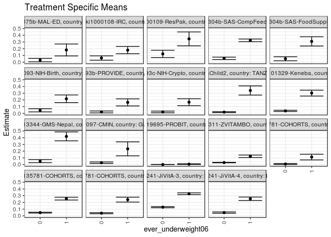

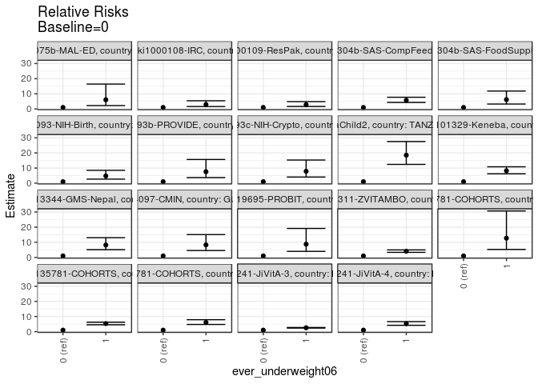

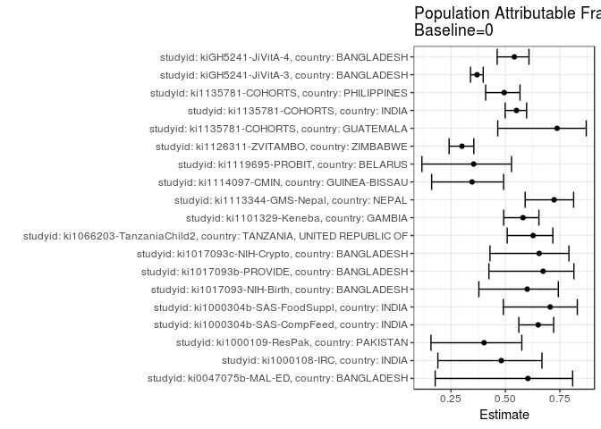

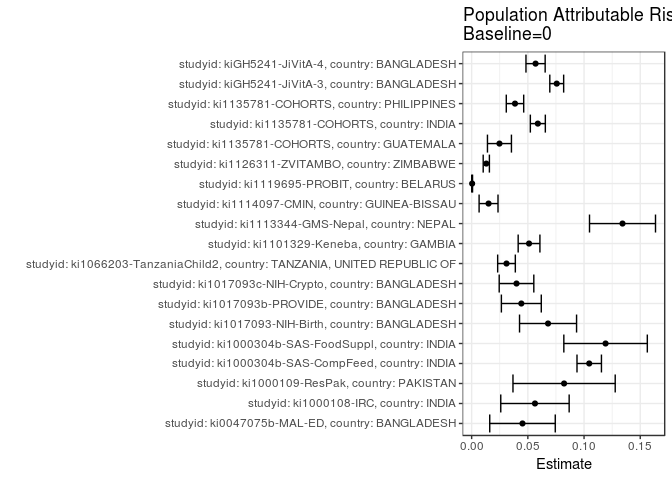

## Results Table

### Parameter: TSM

| studyid | country | intervention_level | baseline_level | estimate | ci_lower | ci_upper |
| --- | --- | --- | --- | --- | --- | --- |
| ki0047075b-MAL-ED | BANGLADESH | 0 | NA | 0.0297619 | 0.0040124 | 0.0555115 |
| ki0047075b-MAL-ED | BANGLADESH | 1 | NA | 0.1805556 | 0.0915220 | 0.2695891 |
| ki1000108-IRC | INDIA | 0 | NA | 0.0607477 | 0.0287051 | 0.0927902 |
| ki1000108-IRC | INDIA | 1 | NA | 0.1785714 | 0.1248879 | 0.2322550 |
| ki1000109-ResPak | PAKISTAN | 0 | NA | 0.1223022 | 0.0677113 | 0.1768930 |
| ki1000109-ResPak | PAKISTAN | 1 | NA | 0.3456790 | 0.2418720 | 0.4494860 |
| ki1000304b-SAS-CompFeed | INDIA | 0 | NA | 0.0562347 | 0.0379052 | 0.0745643 |
| ki1000304b-SAS-CompFeed | INDIA | 1 | NA | 0.3238095 | 0.3039355 | 0.3436835 |
| ki1000304b-SAS-FoodSuppl | INDIA | 0 | NA | 0.0497512 | 0.0196521 | 0.0798504 |
| ki1000304b-SAS-FoodSuppl | INDIA | 1 | NA | 0.3081395 | 0.2390440 | 0.3772350 |
| ki1017093-NIH-Birth | BANGLADESH | 0 | NA | 0.0453074 | 0.0220956 | 0.0685193 |
| ki1017093-NIH-Birth | BANGLADESH | 1 | NA | 0.2167488 | 0.1600135 | 0.2734841 |
| ki1017093b-PROVIDE | BANGLADESH | 0 | NA | 0.0214797 | 0.0075867 | 0.0353727 |
| ki1017093b-PROVIDE | BANGLADESH | 1 | NA | 0.1631579 | 0.1105739 | 0.2157419 |
| ki1017093c-NIH-Crypto | BANGLADESH | 0 | NA | 0.0210325 | 0.0087262 | 0.0333388 |
| ki1017093c-NIH-Crypto | BANGLADESH | 1 | NA | 0.1658291 | 0.1141184 | 0.2175399 |
| ki1066203-TanzaniaChild2 | TANZANIA, UNITED REPUBLIC OF | 0 | NA | 0.0184226 | 0.0120970 | 0.0247481 |
| ki1066203-TanzaniaChild2 | TANZANIA, UNITED REPUBLIC OF | 1 | NA | 0.3405405 | 0.2722354 | 0.4088457 |
| ki1101329-Keneba | GAMBIA | 0 | NA | 0.0368899 | 0.0280868 | 0.0456930 |
| ki1101329-Keneba | GAMBIA | 1 | NA | 0.3016627 | 0.2578096 | 0.3455158 |
| ki1113344-GMS-Nepal | NEPAL | 0 | NA | 0.0513514 | 0.0288427 | 0.0738600 |
| ki1113344-GMS-Nepal | NEPAL | 1 | NA | 0.4198113 | 0.3533200 | 0.4863027 |
| ki1114097-CMIN | GUINEA-BISSAU | 0 | NA | 0.0282903 | 0.0168868 | 0.0396938 |
| ki1114097-CMIN | GUINEA-BISSAU | 1 | NA | 0.2343750 | 0.1305338 | 0.3382162 |
| ki1119695-PROBIT | BELARUS | 0 | NA | 0.0007852 | 0.0000498 | 0.0015206 |
| ki1119695-PROBIT | BELARUS | 1 | NA | 0.0068611 | 0.0013588 | 0.0123634 |
| ki1126311-ZVITAMBO | ZIMBABWE | 0 | NA | 0.0303154 | 0.0263883 | 0.0342426 |
| ki1126311-ZVITAMBO | ZIMBABWE | 1 | NA | 0.1235294 | 0.1048332 | 0.1422256 |
| ki1135781-COHORTS | GUATEMALA | 0 | NA | 0.0088235 | 0.0017906 | 0.0158564 |
| ki1135781-COHORTS | GUATEMALA | 1 | NA | 0.1121495 | 0.0698483 | 0.1544508 |
| ki1135781-COHORTS | INDIA | 0 | NA | 0.0480381 | 0.0415740 | 0.0545021 |
| ki1135781-COHORTS | INDIA | 1 | NA | 0.2561784 | 0.2351712 | 0.2771856 |
| ki1135781-COHORTS | PHILIPPINES | 0 | NA | 0.0394796 | 0.0313940 | 0.0475652 |
| ki1135781-COHORTS | PHILIPPINES | 1 | NA | 0.2414449 | 0.2048655 | 0.2780243 |
| kiGH5241-JiVitA-3 | BANGLADESH | 0 | NA | 0.1290872 | 0.1208720 | 0.1373024 |
| kiGH5241-JiVitA-3 | BANGLADESH | 1 | NA | 0.3288666 | 0.3153369 | 0.3423962 |
| kiGH5241-JiVitA-4 | BANGLADESH | 0 | NA | 0.0482625 | 0.0383008 | 0.0582243 |
| kiGH5241-JiVitA-4 | BANGLADESH | 1 | NA | 0.2537851 | 0.2273375 | 0.2802328 |

### Parameter: E(Y)

| studyid | country | intervention_level | baseline_level | estimate | ci_lower | ci_upper |
| --- | --- | --- | --- | --- | --- | --- |
| ki0047075b-MAL-ED | BANGLADESH | NA | NA | 0.0750000 | 0.0416074 | 0.1083926 |
| ki1000108-IRC | INDIA | NA | NA | 0.1170732 | 0.0859146 | 0.1482317 |
| ki1000109-ResPak | PAKISTAN | NA | NA | 0.2045455 | 0.1511224 | 0.2579685 |
| ki1000304b-SAS-CompFeed | INDIA | NA | NA | 0.1608340 | 0.1401010 | 0.1815669 |
| ki1000304b-SAS-FoodSuppl | INDIA | NA | NA | 0.1689008 | 0.1308276 | 0.2069740 |
| ki1017093-NIH-Birth | BANGLADESH | NA | NA | 0.1132813 | 0.0858017 | 0.1407608 |
| ki1017093b-PROVIDE | BANGLADESH | NA | NA | 0.0656814 | 0.0459906 | 0.0853723 |
| ki1017093c-NIH-Crypto | BANGLADESH | NA | NA | 0.0609418 | 0.0434802 | 0.0784034 |
| ki1066203-TanzaniaChild2 | TANZANIA, UNITED REPUBLIC OF | NA | NA | 0.0494277 | 0.0397346 | 0.0591208 |
| ki1101329-Keneba | GAMBIA | NA | NA | 0.0879524 | 0.0760686 | 0.0998361 |
| ki1113344-GMS-Nepal | NEPAL | NA | NA | 0.1855670 | 0.1539560 | 0.2171780 |
| ki1114097-CMIN | GUINEA-BISSAU | NA | NA | 0.0433295 | 0.0298471 | 0.0568120 |
| ki1119695-PROBIT | BELARUS | NA | NA | 0.0012159 | 0.0002433 | 0.0021885 |
| ki1126311-ZVITAMBO | ZIMBABWE | NA | NA | 0.0433455 | 0.0390195 | 0.0476714 |
| ki1135781-COHORTS | GUATEMALA | NA | NA | 0.0335570 | 0.0217456 | 0.0453685 |
| ki1135781-COHORTS | INDIA | NA | NA | 0.1069236 | 0.0990137 | 0.1148335 |
| ki1135781-COHORTS | PHILIPPINES | NA | NA | 0.0780399 | 0.0680219 | 0.0880579 |
| kiGH5241-JiVitA-3 | BANGLADESH | NA | NA | 0.2047810 | 0.1972350 | 0.2123271 |
| kiGH5241-JiVitA-4 | BANGLADESH | NA | NA | 0.1051267 | 0.0943582 | 0.1158951 |

### Parameter: RR

| studyid | country | intervention_level | baseline_level | estimate | ci_lower | ci_upper |
| --- | --- | --- | --- | --- | --- | --- |
| ki0047075b-MAL-ED | BANGLADESH | 0 | 0 | 1.000000 | 1.000000 | 1.000000 |
| ki0047075b-MAL-ED | BANGLADESH | 1 | 0 | 6.066667 | 2.241101 | 16.422483 |
| ki1000108-IRC | INDIA | 0 | 0 | 1.000000 | 1.000000 | 1.000000 |
| ki1000108-IRC | INDIA | 1 | 0 | 2.939560 | 1.601810 | 5.394532 |
| ki1000109-ResPak | PAKISTAN | 0 | 0 | 1.000000 | 1.000000 | 1.000000 |
| ki1000109-ResPak | PAKISTAN | 1 | 0 | 2.826434 | 1.650439 | 4.840368 |
| ki1000304b-SAS-CompFeed | INDIA | 0 | 0 | 1.000000 | 1.000000 | 1.000000 |
| ki1000304b-SAS-CompFeed | INDIA | 1 | 0 | 5.758178 | 4.288815 | 7.730950 |
| ki1000304b-SAS-FoodSuppl | INDIA | 0 | 0 | 1.000000 | 1.000000 | 1.000000 |
| ki1000304b-SAS-FoodSuppl | INDIA | 1 | 0 | 6.193605 | 3.248869 | 11.807415 |
| ki1017093-NIH-Birth | BANGLADESH | 0 | 0 | 1.000000 | 1.000000 | 1.000000 |
| ki1017093-NIH-Birth | BANGLADESH | 1 | 0 | 4.783955 | 2.691108 | 8.504387 |
| ki1017093b-PROVIDE | BANGLADESH | 0 | 0 | 1.000000 | 1.000000 | 1.000000 |
| ki1017093b-PROVIDE | BANGLADESH | 1 | 0 | 7.595906 | 3.687553 | 15.646636 |
| ki1017093c-NIH-Crypto | BANGLADESH | 0 | 0 | 1.000000 | 1.000000 | 1.000000 |
| ki1017093c-NIH-Crypto | BANGLADESH | 1 | 0 | 7.884422 | 4.062799 | 15.300810 |
| ki1066203-TanzaniaChild2 | TANZANIA, UNITED REPUBLIC OF | 0 | 0 | 1.000000 | 1.000000 | 1.000000 |
| ki1066203-TanzaniaChild2 | TANZANIA, UNITED REPUBLIC OF | 1 | 0 | 18.484966 | 12.419970 | 27.511658 |
| ki1101329-Keneba | GAMBIA | 0 | 0 | 1.000000 | 1.000000 | 1.000000 |
| ki1101329-Keneba | GAMBIA | 1 | 0 | 8.177380 | 6.183888 | 10.813510 |
| ki1113344-GMS-Nepal | NEPAL | 0 | 0 | 1.000000 | 1.000000 | 1.000000 |
| ki1113344-GMS-Nepal | NEPAL | 1 | 0 | 8.175273 | 5.129717 | 13.029001 |
| ki1114097-CMIN | GUINEA-BISSAU | 0 | 0 | 1.000000 | 1.000000 | 1.000000 |
| ki1114097-CMIN | GUINEA-BISSAU | 1 | 0 | 8.284647 | 4.551345 | 15.080239 |
| ki1119695-PROBIT | BELARUS | 0 | 0 | 1.000000 | 1.000000 | 1.000000 |
| ki1119695-PROBIT | BELARUS | 1 | 0 | 8.738136 | 3.991889 | 19.127540 |
| ki1126311-ZVITAMBO | ZIMBABWE | 0 | 0 | 1.000000 | 1.000000 | 1.000000 |
| ki1126311-ZVITAMBO | ZIMBABWE | 1 | 0 | 4.074801 | 3.338772 | 4.973088 |
| ki1135781-COHORTS | GUATEMALA | 0 | 0 | 1.000000 | 1.000000 | 1.000000 |
| ki1135781-COHORTS | GUATEMALA | 1 | 0 | 12.710280 | 5.262519 | 30.698462 |
| ki1135781-COHORTS | INDIA | 0 | 0 | 1.000000 | 1.000000 | 1.000000 |
| ki1135781-COHORTS | INDIA | 1 | 0 | 5.332823 | 4.555349 | 6.242991 |
| ki1135781-COHORTS | PHILIPPINES | 0 | 0 | 1.000000 | 1.000000 | 1.000000 |
| ki1135781-COHORTS | PHILIPPINES | 1 | 0 | 6.115689 | 4.740332 | 7.890090 |
| kiGH5241-JiVitA-3 | BANGLADESH | 0 | 0 | 1.000000 | 1.000000 | 1.000000 |
| kiGH5241-JiVitA-3 | BANGLADESH | 1 | 0 | 2.547631 | 2.362662 | 2.747081 |
| kiGH5241-JiVitA-4 | BANGLADESH | 0 | 0 | 1.000000 | 1.000000 | 1.000000 |
| kiGH5241-JiVitA-4 | BANGLADESH | 1 | 0 | 5.258428 | 4.175393 | 6.622387 |

### Parameter: PAR

| studyid | country | intervention_level | baseline_level | estimate | ci_lower | ci_upper |
| --- | --- | --- | --- | --- | --- | --- |
| ki0047075b-MAL-ED | BANGLADESH | 0 | NA | 0.0452381 | 0.0160859 | 0.0743903 |
| ki1000108-IRC | INDIA | 0 | NA | 0.0563255 | 0.0258989 | 0.0867521 |
| ki1000109-ResPak | PAKISTAN | 0 | NA | 0.0822433 | 0.0367642 | 0.1277223 |
| ki1000304b-SAS-CompFeed | INDIA | 0 | NA | 0.1045992 | 0.0937240 | 0.1154744 |
| ki1000304b-SAS-FoodSuppl | INDIA | 0 | NA | 0.1191496 | 0.0820129 | 0.1562862 |
| ki1017093-NIH-Birth | BANGLADESH | 0 | NA | 0.0679738 | 0.0426049 | 0.0933427 |
| ki1017093b-PROVIDE | BANGLADESH | 0 | NA | 0.0442017 | 0.0264492 | 0.0619542 |
| ki1017093c-NIH-Crypto | BANGLADESH | 0 | NA | 0.0399093 | 0.0245163 | 0.0553024 |
| ki1066203-TanzaniaChild2 | TANZANIA, UNITED REPUBLIC OF | 0 | NA | 0.0310051 | 0.0231536 | 0.0388566 |
| ki1101329-Keneba | GAMBIA | 0 | NA | 0.0510625 | 0.0413868 | 0.0607381 |
| ki1113344-GMS-Nepal | NEPAL | 0 | NA | 0.1342157 | 0.1048607 | 0.1635706 |
| ki1114097-CMIN | GUINEA-BISSAU | 0 | NA | 0.0150392 | 0.0066299 | 0.0234486 |
| ki1119695-PROBIT | BELARUS | 0 | NA | 0.0004307 | 0.0000673 | 0.0007941 |
| ki1126311-ZVITAMBO | ZIMBABWE | 0 | NA | 0.0130300 | 0.0102727 | 0.0157874 |
| ki1135781-COHORTS | GUATEMALA | 0 | NA | 0.0247335 | 0.0140692 | 0.0353978 |
| ki1135781-COHORTS | INDIA | 0 | NA | 0.0588856 | 0.0522204 | 0.0655507 |
| ki1135781-COHORTS | PHILIPPINES | 0 | NA | 0.0385603 | 0.0308178 | 0.0463029 |
| kiGH5241-JiVitA-3 | BANGLADESH | 0 | NA | 0.0756939 | 0.0695342 | 0.0818535 |
| kiGH5241-JiVitA-4 | BANGLADESH | 0 | NA | 0.0568641 | 0.0483285 | 0.0653998 |

### Parameter: PAF

| studyid | country | intervention_level | baseline_level | estimate | ci_lower | ci_upper |
| --- | --- | --- | --- | --- | --- | --- |
| ki0047075b-MAL-ED | BANGLADESH | 0 | NA | 0.6031746 | 0.1776718 | 0.8085066 |
| ki1000108-IRC | INDIA | 0 | NA | 0.4811137 | 0.1899843 | 0.6676077 |
| ki1000109-ResPak | PAKISTAN | 0 | NA | 0.4020783 | 0.1583273 | 0.5752383 |
| ki1000304b-SAS-CompFeed | INDIA | 0 | NA | 0.6503554 | 0.5615139 | 0.7211968 |
| ki1000304b-SAS-FoodSuppl | INDIA | 0 | NA | 0.7054410 | 0.4903219 | 0.8297651 |
| ki1017093-NIH-Birth | BANGLADESH | 0 | NA | 0.6000446 | 0.3782778 | 0.7427077 |
| ki1017093b-PROVIDE | BANGLADESH | 0 | NA | 0.6729714 | 0.4242323 | 0.8142520 |
| ki1017093c-NIH-Crypto | BANGLADESH | 0 | NA | 0.6548757 | 0.4291256 | 0.7913538 |
| ki1066203-TanzaniaChild2 | TANZANIA, UNITED REPUBLIC OF | 0 | NA | 0.6272824 | 0.5081461 | 0.7175616 |
| ki1101329-Keneba | GAMBIA | 0 | NA | 0.5805695 | 0.4920789 | 0.6536432 |
| ki1113344-GMS-Nepal | NEPAL | 0 | NA | 0.7232733 | 0.5905228 | 0.8129867 |
| ki1114097-CMIN | GUINEA-BISSAU | 0 | NA | 0.3470900 | 0.1614545 | 0.4916299 |
| ki1119695-PROBIT | BELARUS | 0 | NA | 0.3542236 | 0.1166729 | 0.5278905 |
| ki1126311-ZVITAMBO | ZIMBABWE | 0 | NA | 0.3006087 | 0.2416541 | 0.3549802 |
| ki1135781-COHORTS | GUATEMALA | 0 | NA | 0.7370588 | 0.4648135 | 0.8708150 |
| ki1135781-COHORTS | INDIA | 0 | NA | 0.5507255 | 0.4989138 | 0.5971799 |
| ki1135781-COHORTS | PHILIPPINES | 0 | NA | 0.4941104 | 0.4091750 | 0.5668357 |
| kiGH5241-JiVitA-3 | BANGLADESH | 0 | NA | 0.3696331 | 0.3398147 | 0.3981047 |
| kiGH5241-JiVitA-4 | BANGLADESH | 0 | NA | 0.5409105 | 0.4621971 | 0.6081034 |